# IS 607 - Week 7 / 8 Assignment

Suman K Polavarapu

Friday, March 20, 2015

# Activity Definition:

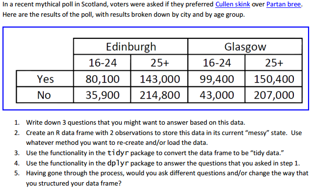

## Setup:

```r
#Load the required libraries for data analysis.
library(tidyr)
library(dplyr)
```

## Analysis:

### Write down 3 questions that you might want to answer based on this data.

**Which city had more number of people participated in the poll ?**

**What is the Age group with highest, lowest support for Cullen from each city ?**

**What is the proportion of the age groups participated in the polls ?**

**What is the overall support for Cullen ?**

### Create an R data frame with 2 observations to store this data in its current “messy” state. Use whatever method you want to re-create and/or load the data.

```r
response = c("Yes", "No")
edinburgh.16_24 = c(80100, 35900)
edinburgh.25_plus = c(143000, 214800)
glasgow.16_24 = c(99400, 43000)
glasgow.25_plus = c(150400, 207000)

data_orig <- tbl_df(data.frame(response, edinburgh.16_24, edinburgh.25_plus, glasgow.16_24, glasgow.25_plus))
colnames(data_orig)[1] <- "prefer_cullen"

data_orig
```

```
## Source: local data frame [2 x 5]
##
##   prefer_cullen edinburgh.16_24 edinburgh.25_plus glasgow.16_24
## 1           Yes           80100            143000         99400
## 2            No           35900            214800         43000
## Variables not shown: glasgow.25_plus (dbl)
```

### Use the functionality in the tidyr package to convert the data frame to be “tidy data.”

```r
data_tidy <- data_orig %>%
              gather(key = city_agegroup, value = count, -prefer_cullen) %>%
                separate(col = city_agegroup, into=c("city", "agegroup"), sep = "\\.")

data_tidy
```

```
## Source: local data frame [8 x 4]
##
##   prefer_cullen      city agegroup  count
## 1           Yes edinburgh    16_24  80100
## 2            No edinburgh    16_24  35900
## 3           Yes edinburgh  25_plus 143000
## 4            No edinburgh  25_plus 214800
## 5           Yes   glasgow    16_24  99400
## 6            No   glasgow    16_24  43000
## 7           Yes   glasgow  25_plus 150400
## 8            No   glasgow  25_plus 207000
```

### Use the functionality in the dplyr package to answer the questions that you asked previously.

**Which city had more number of people participated in the poll ?**

```r
data_tidy %>%
  group_by(city) %>%
    summarise(total = sum(count)) %>%
      arrange(desc(total)) %>%
        top_n(1)
```

```
## Source: local data frame [1 x 2]
##
##      city  total
## 1 glasgow 499800
```

**What is the Age group with highest, lowest support for Cullen from each city ?**

```r
data_tidy %>%
  filter(prefer_cullen == 'Yes') %>%
    group_by(city, agegroup) %>%
     summarise(total = sum(count)) %>%
              top_n(1, total)
```

```
## Source: local data frame [2 x 3]
## Groups: city
##
##        city agegroup  total
## 1 edinburgh  25_plus 143000
## 2   glasgow  25_plus 150400
```

```r
data_tidy %>%
  filter(prefer_cullen == 'Yes') %>%
    group_by(city, agegroup) %>%
      summarise(total = sum(count)) %>%
        top_n(1, desc(total))
```

```
## Source: local data frame [2 x 3]
## Groups: city
##
##        city agegroup total
## 1 edinburgh    16_24 80100
## 2   glasgow    16_24 99400
```

**What is the proportion of the age groups participated in the polls ?**

```r
age_16_24  <- data_tidy %>%
                    filter(agegroup == '16_24') %>%
                        summarise(total = sum(count))


age_25_plus <- data_tidy %>%
                    filter(agegroup == '25_plus') %>%
                        summarise(total = sum(count))



paste(round((age_16_24)/sum(data_tidy$count) * 100,2) , '% of population is between 16 and 24')
```

```
## [1] "26.54 % of population is between 16 and 24"
```

```r
paste(round((age_25_plus)/sum(data_tidy$count) * 100,2), '% of population is between 25 and above')
```

```
## [1] "73.46 % of population is between 25 and above"
```

**What is the overall support for Cullen ?**

```r
prefer_cullen  <- data_tidy %>%
  filter(prefer_cullen == 'Yes') %>%
      summarise(total = sum(count))

do_not_prefer_cullen <- data_tidy %>%
    filter(prefer_cullen == 'No') %>%
      summarise(total = sum(count))

paste(round((prefer_cullen)/sum(data_tidy$count) * 100,2) , '% of population prefer Cullen')
```

```
## [1] "48.57 % of population prefer Cullen"
```

```r
paste(round((do_not_prefer_cullen)/sum(data_tidy$count) * 100,2) , '% of population do NOT prefer Cullen')
```

```
## [1] "51.43 % of population do NOT prefer Cullen"
```

From the above analysis, it appears like Partan Bree has got slightly more support than Cullen Skink. With the given data, the above tidy data set appears to be sufficient for this analysis, however it gets tricky when we need to anwer questions based on the mulitple factors like age group, city. Probably by combining age groups could simplify the data frame to look at just the majority preference in each city and overall.